# Wrangling_Project_Shark_attacks

ZhihaoLin

2018/4/11

```r
urls <- c("https://docs.google.com/spreadsheet/pub?key=phAwcNAVuyj0NpF2PTov2Cw&output=xlsx",
          "https://docs.google.com/spreadsheet/pub?key=phAwcNAVuyj2tPLxKvvnNPA&output=xlsx",
          "https://docs.google.com/spreadsheet/pub?key=phAwcNAVuyj0TAlJeCEzcGQ&output=xlsx",
          "https://docs.google.com/spreadsheet/pub?key=phAwcNAVuyj0XOoBL_n5tAQ&output=xlsx",
          "https://docs.google.com/spreadsheet/pub?key=0AkBd6lyS3EmpdHo5S0J6ekhVOF9QaVhod05QSGV4T3c&output=xlsx",
          "https://docs.google.com/spreadsheet/pub?key=pyj6tScZqmEcVezxiMlWaRw&output=xlsx",
          "https://docs.google.com/spreadsheet/pub?key=pyj6tScZqmEeL79qOoKtofQ&output=xlsx",
          "https://docs.google.com/spreadsheet/pub?key=pyj6tScZqmEcjeKHnZq6RIg&output=xlsx"
          )

measures <- c("infant_mortality", "life_expectancy", "fertility","population","gdp",
              "maternal_mortality", "health_spending", "gini")

for (i in 1:length(urls)){
  if (!file.exists(paste0(measures[i], ".xlsx")))
  download.file(urls[i], destfile = paste0(measures[i], ".xlsx"), method = "auto")
}

gap_raw <- purrr::map(paste0(measures, ".xlsx"), read_excel, na = c("", "NA", "-", "."))
names(gap_raw) <- measures

## Convert list to tidy dataset. I haven't figure out how to use map() so I use a for-loop
gap_new <- NULL

for (i in 1:8) {
  gap_new[[i]] <- gather(gap_raw[[i]], names(gap_raw[[i]][, 2:dim(gap_raw[[i]])[2]]), key = "year", value = "count")
}

names(gap_new) <- measures

## Join list of data frames into a single data frame
for (i in 1:8) {
  gap_new[[i]]$year <- as.numeric(gap_new[[i]]$year)
  colnames(gap_new[[i]])[1] <- "country"
  colnames(gap_new[[i]])[3] <- names(gap_new[i])
}

gap_tb <- plyr::join_all(gap_new, type = "full")
co_na <- colnames(gap_tb)
co_na[1] <- "Country"
co_na[2] <- "Year"
colnames(gap_tb) <- co_na
gap_tb$Country<-str_replace_all(gap_tb$Country,"United States","USA")
gap_tb$Country <- toupper(gap_tb$Country)
```

```r
attacks <- read_csv("~/attacks.csv")%>%
  filter(`Case Number`!=0)%>%
  select(-c(Date,X23,X24))%>%
  mutate(order=`original order`)%>%
  filter(Year>=1800)
attacks$order <-as.character(attacks$order)
attacks$`Fatal (Y/N)`<-attacks$`Fatal (Y/N)`%>%
  str_replace("Y","1")%>%
  str_replace("N","0")%>%
  str_replace("2017","0")%>%
  as.numeric()
Spe <- attacks%>%
  unnest_tokens(specy,Species)%>%
  filter(toupper(specy)%in%c("WHITE","BULL","BLACKTIP","ANGEL","GOBLIN","TIGER","BASKING","COPPER","HAMMERHEAD","COOKIECUTTER","NURSE","WHITETIP"))%>%
  select(order,specy)
attacks <- left_join(attacks,Spe,by="order")%>%
  select(-c(order,pdf:href))%>%
  left_join(gap_tb,by=c("Country","Year"))
```

```r
tourism <- read_csv("~/API_ST.INT.ARVL_DS2_en_csv_v2.csv",  skip = 4)%>%
  select(-c(5:39,62,63))%>%
  na.omit()%>%
  gather(5:26,key="Year",value="International_Tourism")
colnames(tourism)[1]<-"Country"
tourism$Year <- as.numeric(tourism$Year)
tourism$Country <- str_replace_all(tourism$Country,"United States","USA")
tourism$Country <- toupper(tourism$Country)

attacks <- attacks%>%
  left_join(tourism,by=c("Country","Year"))%>%select(-c(29:30))
act <- attacks%>%
  unnest_tokens(Act,Activity)%>%
  select(Act,`original order`)
top_acts <-act%>%
  mutate(n=1)%>%
  group_by(Act)%>%
  summarise(frequency=sum(n))%>%
  arrange(desc(frequency))%>%
  na.omit()%>%
  .[1:5,]
act <- act%>%
  filter(Act%in%c("swimming","fishing","surfing","diving","spearfishing"))
attacks <- attacks%>%
  left_join(act,by="original order")
```

## Since month can describe partially the tempreture, hence here

```r
time <- read_csv("~/Downloads/attacks.csv")%>%
  filter(`Case Number`!=0)%>%
  select(Date,`original order`)%>%
  na.omit()%>%
  .[1:6052,]
time$Date <- time$Date%>%
  str_replace("Reported "," ")
pattern <-"[A-z]+"
time$Date <- time$Date%>%str_extract(pattern)
time_col_names <- colnames(time)
time_col_names[1] <- "Month"
colnames(time) <- time_col_names
Months <- time%>%
  mutate(n=1)%>%
  group_by(Month)%>%
  summarise(time=sum(n))%>%
  arrange(desc(time))%>%
  .[1:12,]
time <- time%>%
  filter(Month%in%Months$Month)
mon <- time$Month
mon <- mon%>%
  str_replace_all("Jan","13_1")%>%
  str_replace_all("Feb","2")%>%
  str_replace_all("Mar","3")%>%
  str_replace_all("Apr","4")%>%
  str_replace_all("May","5")%>%
  str_replace_all("Jun","6")%>%
  str_replace_all("Jul","7")%>%
  str_replace_all("Aug","8")%>%
  str_replace_all("Sep","9")%>%
  str_replace_all("Oct","10")%>%
  str_replace_all("Nov","11")%>%
  str_replace_all("Dec","12")
time$Month <- mon
attacks <- attacks%>%
  left_join(time,by="original order")
```

Area_of_attack <- attacks%>%mutate(n=1)%>% group_by(Area)%>% summarise(attack_of_Area=sum(n))%>% na.omit()%>% arrange(desc(attack_of_Area))%>% .[1:10,]%>% mutate(x=geocode(Area)$lon,y=geocode(Area)$lat) ##Get the geo information of the area

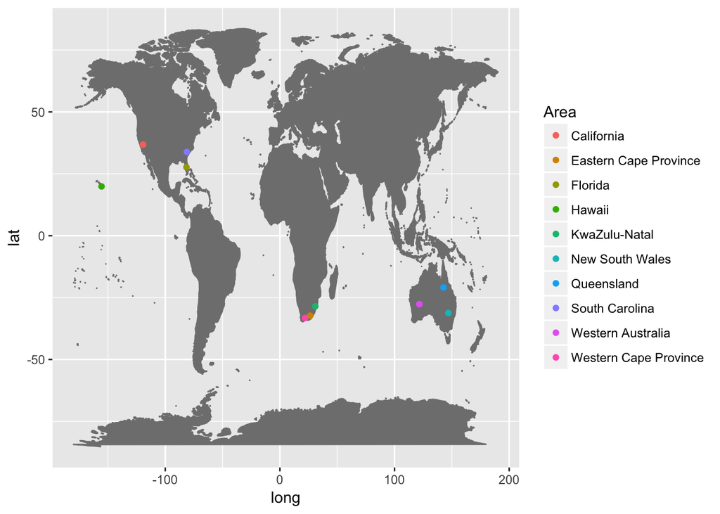

```r
##This code can work but sometimes it is not working that well. In general I need to run it about ten times to get full informations for the dataset. Hence in order to prevent from failure I would rather use the full to write a csv and use it in the future works.
##write.csv(Area_of_attack,"Area_information.csv")
Area_information <- read_csv("~/Downloads/Area_information.csv")

attacks <- attacks%>%left_join(Area_information,by="Area")%>%select(-X1)
mp <- NULL
mapWorld <- borders("world", colour="gray50", fill="gray50")
mp <- ggplot() +   mapWorld
mp <- mp+ geom_point(data=Area_information,aes(x,y,color=Area))
mp
```

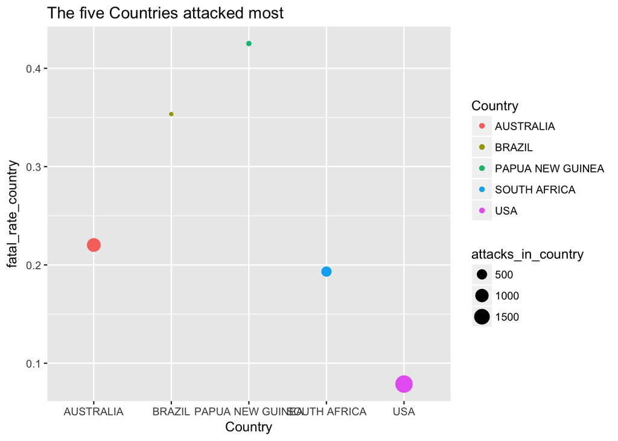

```r
countries_fatality <- attacks%>%
  filter(Year>=1900)%>%
  select(c(Country,`Fatal (Y/N)`))%>%
  na.omit()%>%
  mutate(n=1)%>%
  group_by(Country)%>%
  summarise(attacks_in_country=sum(n),death_in_country=sum(`Fatal (Y/N)`))%>%
  arrange(desc(attacks_in_country))%>%
  mutate(fatal_rate_country=death_in_country/attacks_in_country)
area_fatality_in_top100Area <- attacks%>%
  filter(Year>=1900)%>%
  select(c(Area,`Fatal (Y/N)`))%>%
  na.omit()%>%
  mutate(n=1)%>%
  group_by(Area)%>%
  summarise(attacks_in_area=sum(n),death_in_area=sum(`Fatal (Y/N)`))%>%
  arrange(desc(attacks_in_area))%>%
  .[1:100,]%>%
  mutate(fatal_rate_country=death_in_area/attacks_in_area)
specie_study <- attacks%>%
  filter(Year>=1800)%>%
  select(c(specy,`Fatal (Y/N)`))%>%
  na.omit()%>%
  mutate(n=1)%>%
  group_by(specy)%>%
  summarise(attacks_of_specy=sum(n),death_of_specy=sum(`Fatal (Y/N)`))%>%
  mutate(fatal_rate_specy=death_of_specy/attacks_of_specy)%>%
  arrange(desc(fatal_rate_specy))
countries_fatality%>%
  .[1:5,]%>%ggplot(aes(Country,fatal_rate_country,color = Country, size = attacks_in_country))+geom_point()+ggtitle("The five Countries attacked most")
```

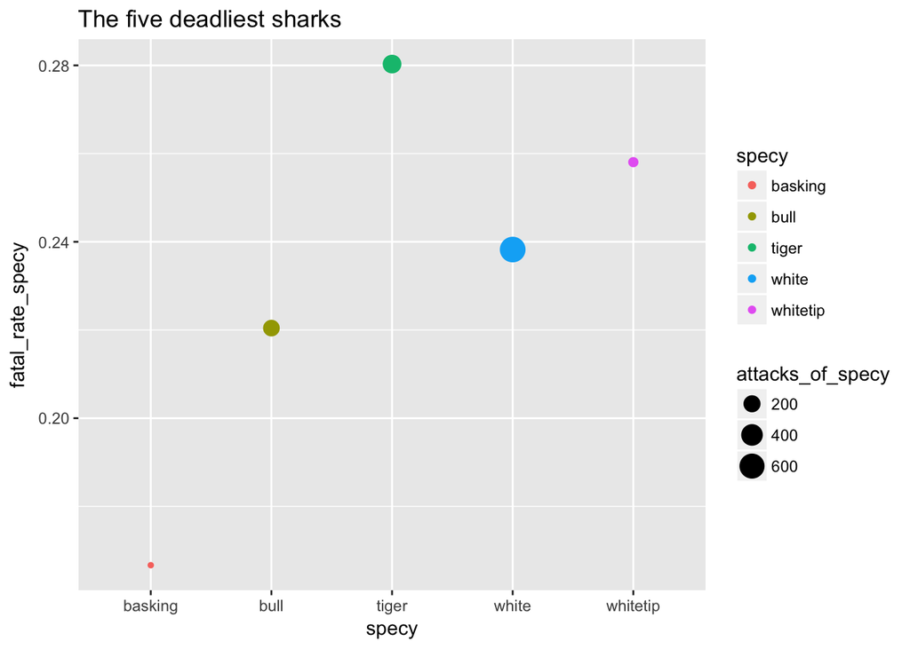

```r
specie_study%>%
  .[1:5,]%>%
  ggplot(aes(specy,fatal_rate_specy,color = specy,size = attacks_of_specy))+geom_point()+ggtitle("The five deadliest sharks")
```

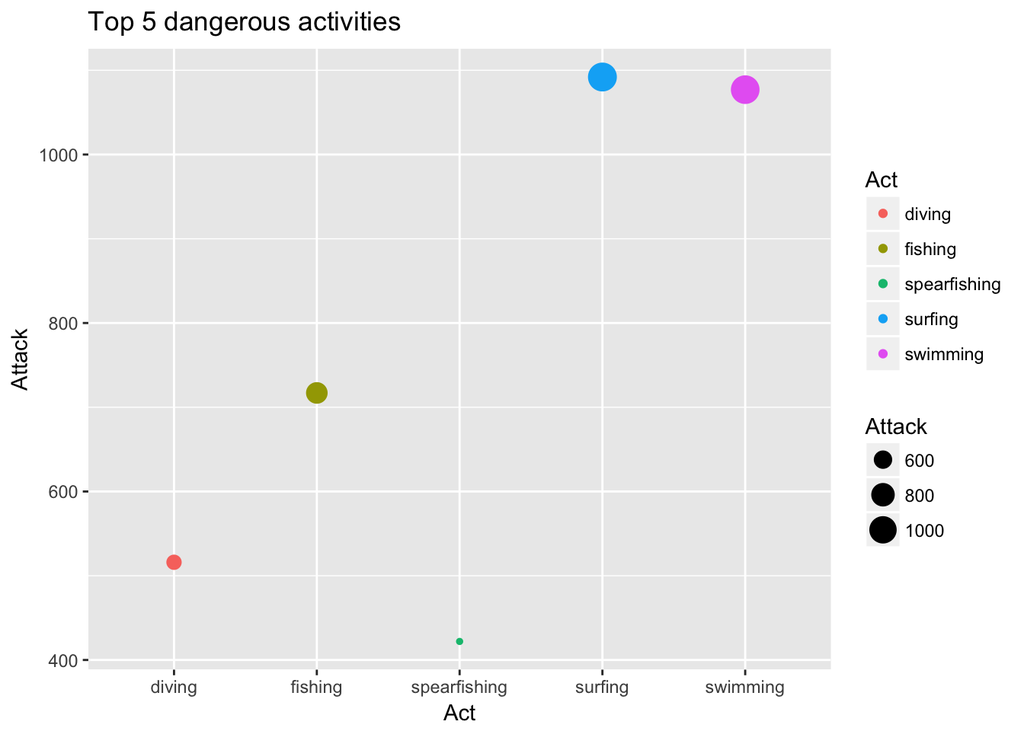

```r
attacks%>%mutate(n=1)%>%group_by(Act)%>%summarise(Attack=sum(n))%>%na.omit()%>%ggplot(aes(Act,Attack,color=Act,size=Attack))+geom_point()+ggtitle("Top 5 dangerous activities")
```

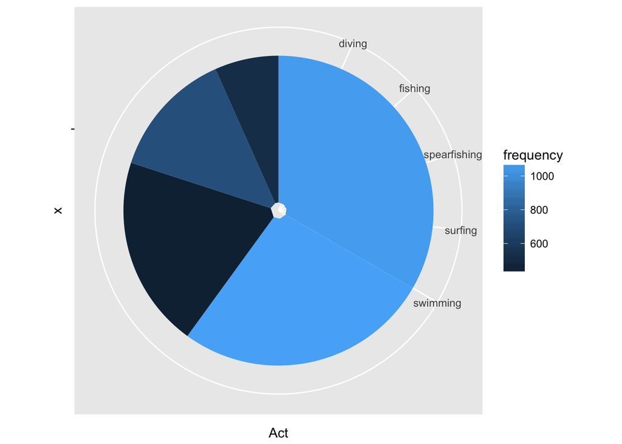

```r
picture_top5 = ggplot(top_acts,aes(x="",y=Act,fill=frequency))+geom_bar(stat = "identity")+coord_polar(theta = "y")
picture_top5
```

##Analysis about if sharks are harmless creatures. Some people claimed that it is our faught to provoke these creatures, however in this analysis it does not seemed this way.

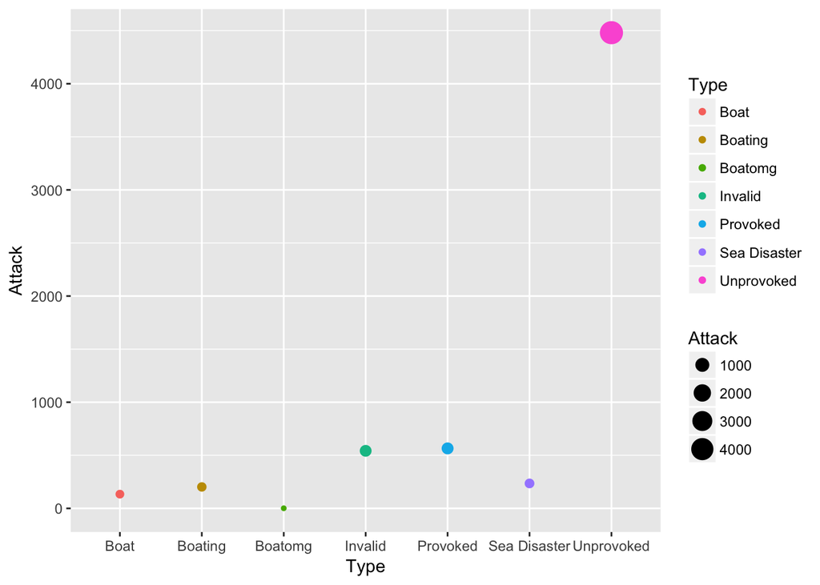

```r
attacks%>%
  mutate(n=1)%>%
  group_by(Type)%>%
  summarise(Attack=sum(n))%>%
  na.omit()%>%
  ggplot(aes(Type,Attack,color=Type,size=Attack))+geom_point()
```

##Since most animals on earth can not addapt with all tempreture, it make sense to analysis the frequency of attacks of different months. And there is some relationship about if people are willing to go to the shore– it is obvious that people can’t just sit in their home and wait for being attacked. Seemed the frequency of attack is much higher during the summer than what it is in the winter. ##I don’t know if I should say since people are more willing to go to the shoreline when the tempreture is high, but there is a tendency of high frequency of attacks when it is hot.

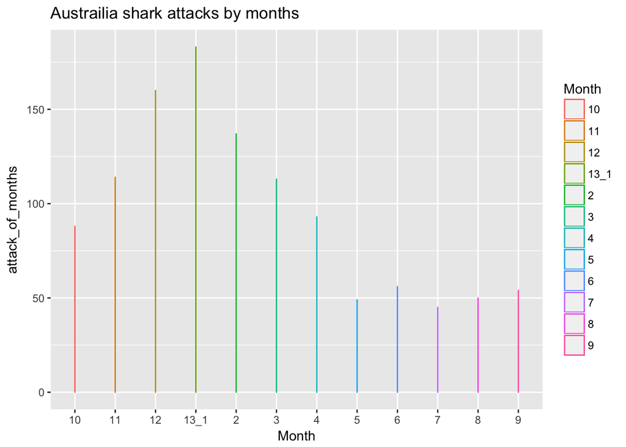

```r
a1 <- attacks%>%
  filter(Country=="USA")%>%
  mutate(n=1)%>%
  filter(Year>=1900)%>%
  group_by(Month)%>%
  summarise(attack_of_months=sum(n))%>%
  na.omit()%>%
  ggplot(aes(Month,attack_of_months,color = Month))+geom_density()+ggtitle("USA shark attacks by months")
attacks%>%
  filter(Country=="AUSTRALIA")%>%
  mutate(n=1)%>%
  filter(Year>=1900)%>%
  group_by(Month)%>%
  summarise(attack_of_months=sum(n))%>%
  na.omit()%>%
  ggplot(aes(Month,attack_of_months,color = Month))+geom_density()+ggtitle("Austrailia shark attacks by months")
```

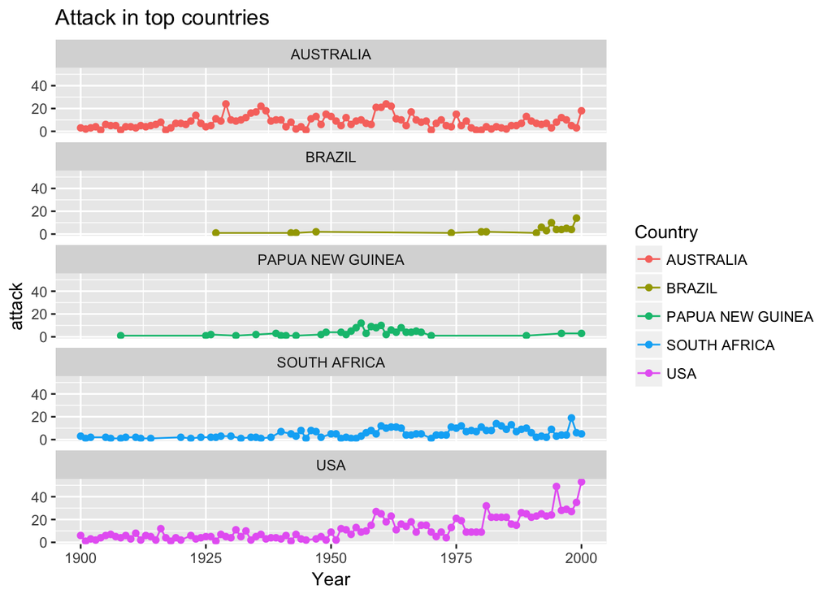

```r
top_countries <- attacks%>%
  group_by(Country,Year)%>%
  mutate(n=1)%>%
  summarise(atk=sum(n),death=sum(`Fatal (Y/N)`))%>%
  na.omit()%>%
  group_by(Country)%>%
  summarise(time=sum(atk),kill=sum(death))%>%
  arrange(desc(time))%>%
  .[1:5,]
Age_bar<-c(10:50)
top_countries%>%
  left_join(attacks,by="Country")%>%
  filter(Year>=1900)%>%
  filter(Year<=2000)%>%
  group_by(Country,Year)%>%
  mutate(n=1)%>%
  summarise(attack=sum(n))%>%
  ggplot(aes(Year,attack,color=Country))+
  facet_wrap( ~ Country, nrow = 5)+geom_line()+geom_point()+ggtitle("Attack in top countries")
```

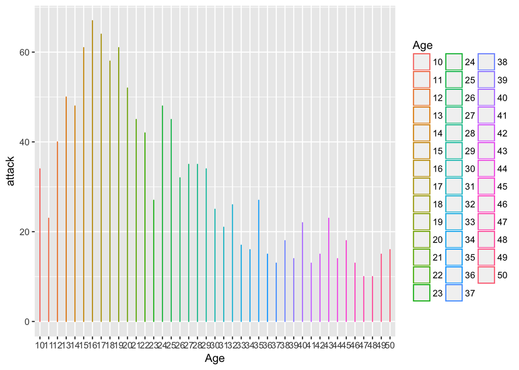

```r
attacks%>%
  filter(Year>=1900)%>%
  filter(Country=="USA")%>%
  mutate(n=1)%>%
  group_by(Age)%>%
  filter(Age%in%Age_bar)%>%
  summarise(attack=sum(n))%>%
  ggplot(aes(Age,attack,color = Age))+geom_density()
```

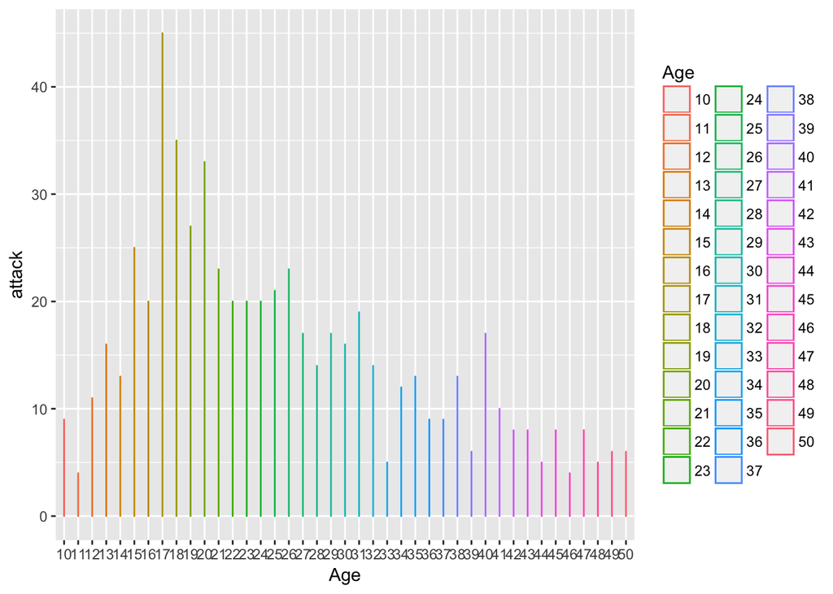

```r
attacks%>%
  filter(Year>=1900)%>%
  filter(Country=="AUSTRALIA")%>%
  mutate(n=1)%>%
  group_by(Age)%>%
  filter(Age%in%Age_bar)%>%
  summarise(attack=sum(n))%>%
  ggplot(aes(Age,attack,color = Age))+geom_density()
```

##It seemed the attacks in the USA is leading, and the standard deviation of attacks in USA is much more than in the Australia. And the mean and median of attacks took place in Austrailia is higher than USA. Maybe the structure of people who go to the shoreline is different in these countries.

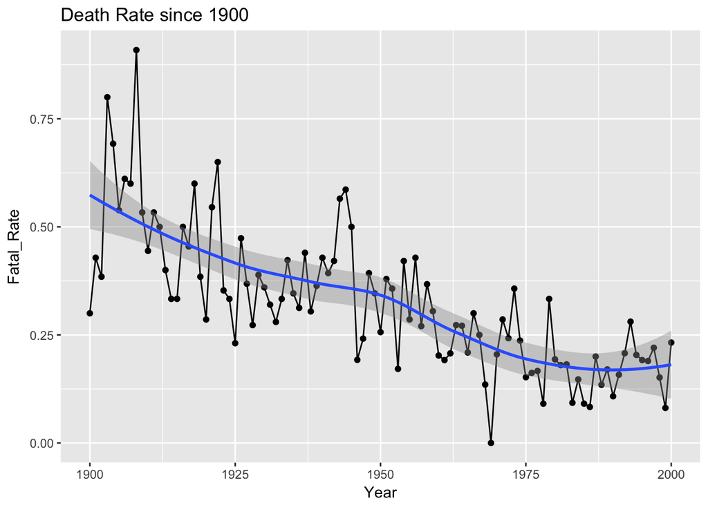

```r
fatality_year<-attacks%>%
  filter(Year>=1900)%>%
  group_by(Year)%>%
  mutate(n=`Fatal (Y/N)`)%>%
  mutate(t=1)%>%
  select(c(Year,n,t))%>%
  na.omit()%>%
  summarise(death=sum(n),attack=sum(t))%>%
  filter(2000>=Year,Year>=1900)%>%
  mutate(Fatal_Rate=death/attack)

ggplot(data=fatality_year,aes(Year,Fatal_Rate))+geom_point()+geom_line()+geom_smooth()+ggtitle("Death Rate since 1900")
```

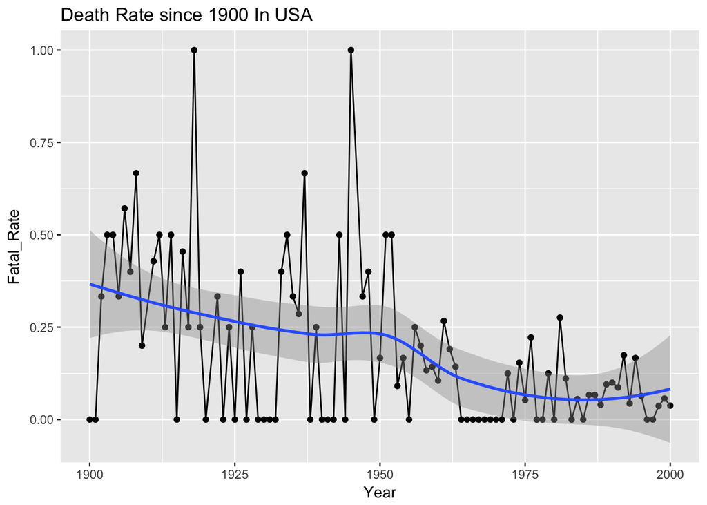

```r
attacks%>%
  filter(Country=="USA")%>%
  filter(Year>=1900)%>%
  group_by(Year)%>%
  mutate(n=`Fatal (Y/N)`)%>%
  mutate(t=1)%>%
  select(c(Year,n,t))%>%
  na.omit()%>%
  summarise(death=sum(n),attack=sum(t))%>%
  filter(2000>=Year,Year>=1900)%>%
  mutate(Fatal_Rate=death/attack)%>%
  ggplot(aes(Year,Fatal_Rate))+geom_point()+geom_line()+geom_smooth()+ggtitle("Death Rate since 1900 In USA")
```

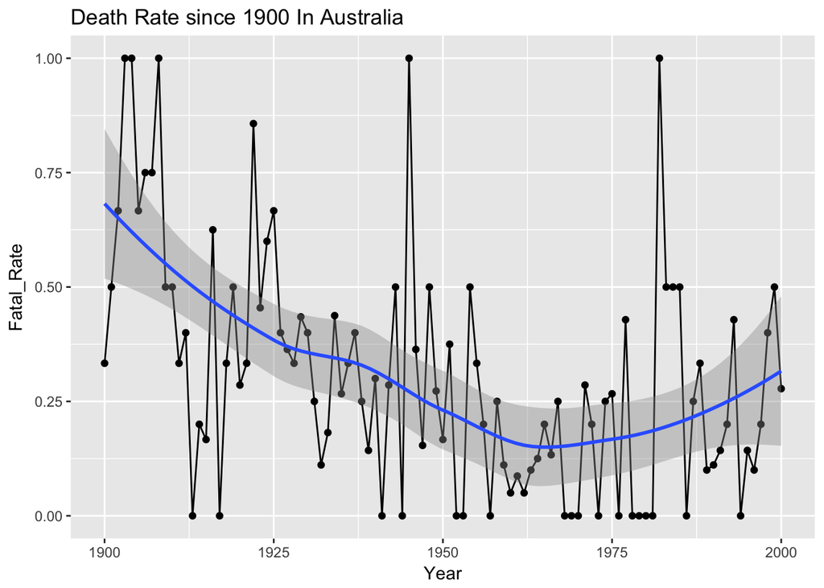

```r
attacks%>%
  filter(Country=="AUSTRALIA")%>%
  filter(Year>=1900)%>%
  group_by(Year)%>%
  mutate(n=`Fatal (Y/N)`)%>%
  mutate(t=1)%>%
  select(c(Year,n,t))%>%
  na.omit()%>%
  summarise(death=sum(n),attack=sum(t))%>%
  filter(2000>=Year,Year>=1900)%>%
  mutate(Fatal_Rate=death/attack)%>%
  ggplot(aes(Year,Fatal_Rate))+geom_point()+geom_line()+geom_smooth()+ggtitle("Death Rate since 1900 In Australia")
```

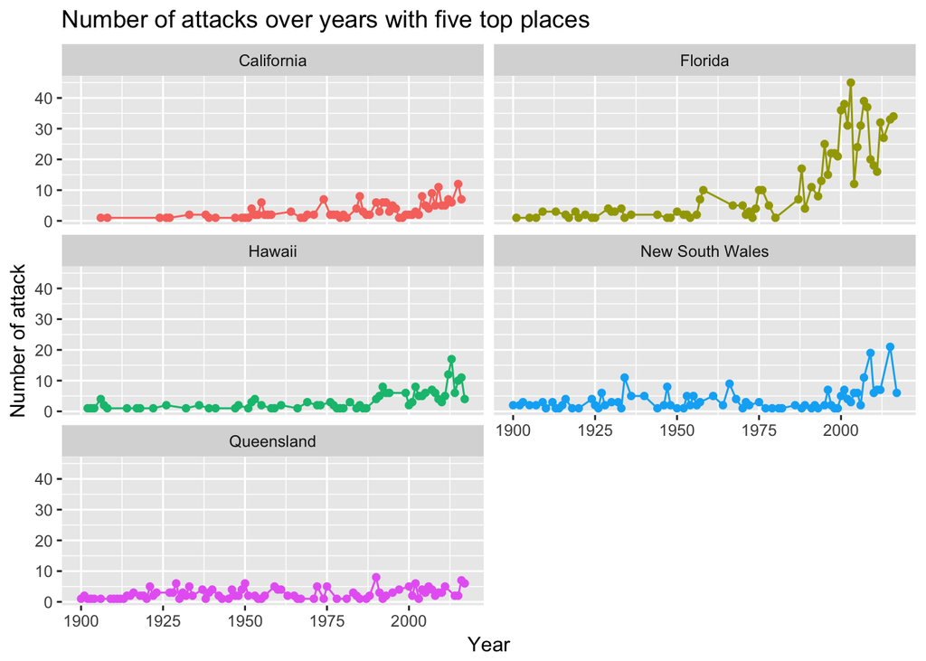

```r
Death_Rate_Place <- attacks%>%
  filter(Area%in%Area_information[1:5,]$Area)%>%
  group_by(Area,Year)%>%
  mutate(n=1)%>%
  summarise(death=sum(`Fatal (Y/N)`),time=sum(n))%>%
  na.omit()%>%
  filter(Year>=1900)%>%
  mutate(rate=death/time)
Death_Rate_Place %>%
  ggplot(aes(Year, time, colour = Area)) + geom_point() + geom_line() +
  facet_wrap( ~ Area, nrow = 3) + ggtitle("Number of attacks over years with five top places") +
  xlab("Year") + ylab("Number of attack") + theme(legend.position = "none")
```